# Class Questionnaire: Pulse vs. Gender

STAT 230

January 26, 2017

## The Data

```r
x <- read.csv("stat_230_survey_raw.csv", as.is = TRUE)
x <- x[x$Gender != "",]
```

Question from last class: do men and women have different pulses on average?

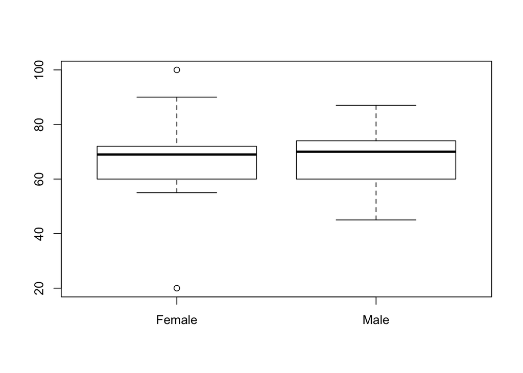

```r
boxplot(Pulse ~ Gender, data=x)
```

## Some Approaches

### Independent 2-Sample t-test

```r
t.test(Pulse ~ Gender, data=x)
```

```
##
##  Welch Two Sample t-test
##
## data:  Pulse by Gender
## t = -0.24258, df = 60.896, p-value = 0.8091
## alternative hypothesis: true difference in means is not equal to 0
## 95 percent confidence interval:
##  -6.162229  4.828895
## sample estimates:
## mean in group Female   mean in group Male
##             68.00000             68.66667
```

How do we interpret the results here? We have a p-value of 0.8091. At any reasonable significance level $\alpha$ (say, 0.05), we do not have evidence to suggest that the mean pulse differs between the genders. We also get a 95% confidence interval of (-6.16, 4.83). We might say that we are 95% confident that the difference $\mu_F-\mu_M$ is between (-6.16, 4.83). How did we know it was $\mu_F-\mu_M$ and not $\mu_M-\mu_F$? Because in the line below ‘sample estimates’, we see ‘Female’ before ‘Male’.

Some questions you may have:

- The p-value here corresponds to a 2-sided alternative hypothesis. What can I do if I wanted a 1-sided alternative hypothesis test instead?

Questions like these can generally be answered by pulling up the help page, i.e. `?t.test`. You will see that you can add the argument `alternative=` to be ‘less’ or ‘greater’, but that it defaults to ‘two.sided’.

- What if I want a confidence interval for a different confidence level?

The help file suggests that `conf.level=` is the argument to be modified.

We did have to make some assumptions about the population when applying the t-test. The most important one is perhaps that the population distributions ought to be normal. What happens if they’re not?

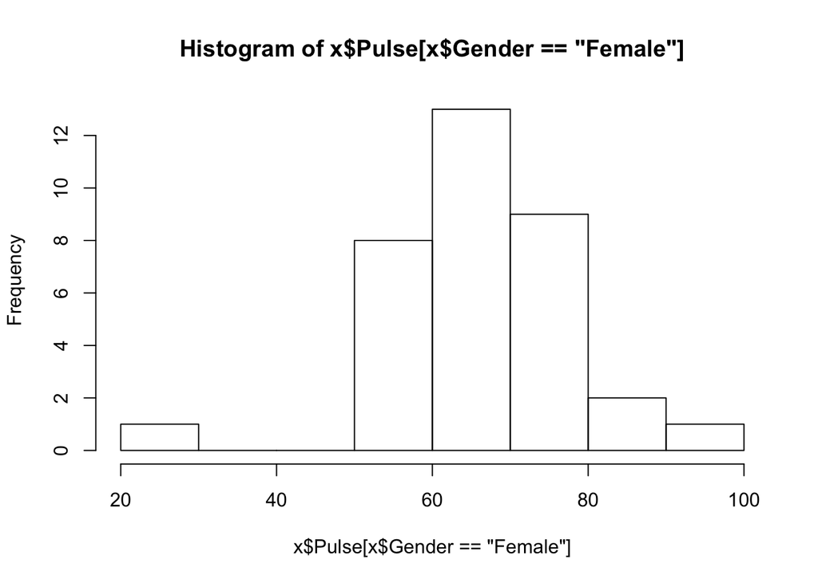

```r
hist(x$Pulse[x$Gender == "Female"])
```

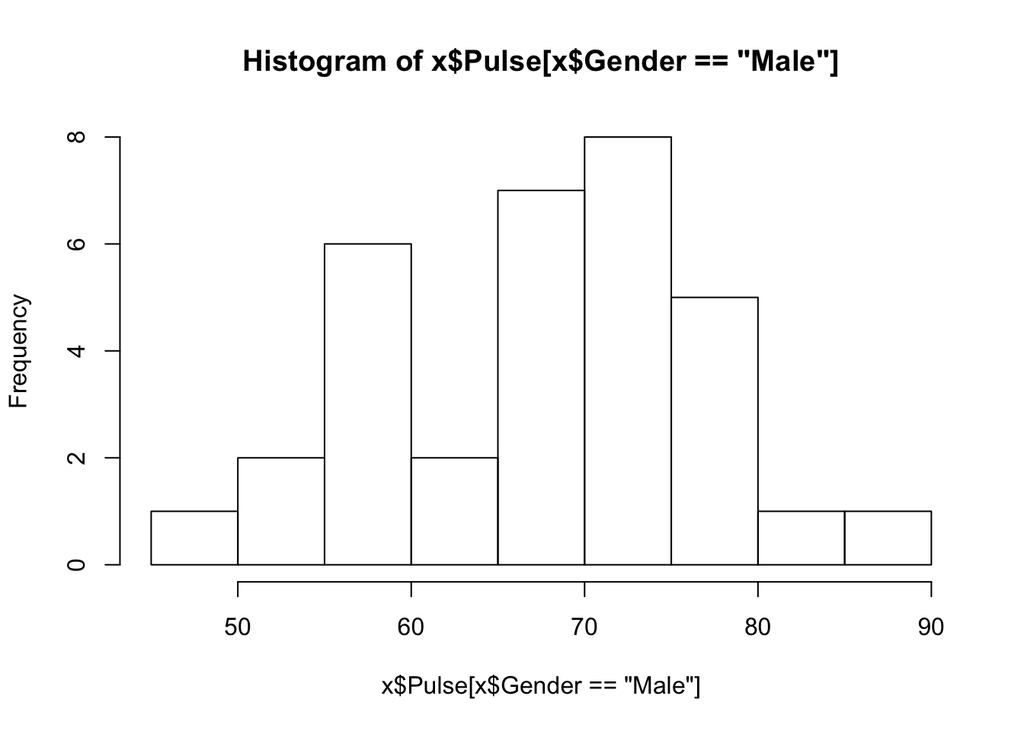

```r
hist(x$Pulse[x$Gender == "Male"])
```

### A Brief Intro to For-Loops (and if-statements)

This is a good time to talk about a for-loop. A for-loop is good for doing some sort of repeated action again and again. Suppose we wanted to count the number of students who expressed at least an 95% chance of taking this class for credit `Pcredit >= 0.95`. This can be thought of as a repeated action; for each `Pcredit` value in the dataset and increment a counter by 1 if the value is at least 0.95.

A for-loop is not the best way to do this, but this is good for practice.

```r
numCreditStudents <- 0
for (i in 1:nrow(x)) {
  if (!is.na(x$Pcredit[i]) & x$Pcredit[i] >= 0.95) {
    numCreditStudents <- numCreditStudents + 1
  }
}
numCreditStudents
```

```
## [1] 62
```

What if we wanted to know the fraction of students who have higher than a 95% probability of taking the class for credit? Then we need to keep track of the denominator as well:

```r
numCreditStudents <- 0
numResponses <- 0
for (i in 1:nrow(x)) {
  if (!is.na(x$Pcredit[i])) {
    numResponses <- numResponses + 1
    if (x$Pcredit[i] >= 0.95) {
      numCreditStudents <- numCreditStudents + 1
    }
  }
}
numCreditStudents/numResponses
```

```
## [1] 0.6813187
```

Can I do this in one line of code? Absolutely:

```r
sum(x$Pcredit >= 0.95, na.rm = TRUE) # this discards the NAs
```

```
## [1] 62
```

```r
sum(x$Pcredit >= 0.95, na.rm = TRUE)/sum(!is.na(x$Pcredit))
```

```
## [1] 0.6813187
```

```r
mean(x$Pcredit >= 0.95, na.rm = TRUE)
```

```
## [1] 0.6813187
```

In summary, there is a time and a place for loops. R is very efficient with vectorized observations like `sum()` and `mean()`, so that if you can avoid using loops, by all means do!

But, today we will show situations where indeed a for-loop-based solution is a natural fit.

### Permutation Test

We’ll learn a different way of addressing the 2-sample mean comparison problem. The permutation test is a general, nonparametric approach that can be used in a wide range of scenarios requiring hypothesis testing (not just this 2-sample problem).

The steps used in a permutation test are as follows:

1. Compute a test statistic related to our hypothesis. (A natural one for us is $\bar X_F-\bar X_M$, the difference in the sample means.)
2. Simulate the distribution of the test statistic under $H_0$.
3. Compare our actual test statistic in Step 1 to the distribution in Step 2. How unusual is our actual test statistic relative to what we would’ve expected if $H_0$ were true?

#### Step 0

It turns out that we have an added complication. There are missing values in `Pulse`!

```r
summary(x$Pulse)
```

```
##    Min. 1st Qu.  Median    Mean 3rd Qu.    Max.    NA's
##   20.00   60.00   70.00   68.33   74.00  100.00      25
```

We will need to remove these missing values before we can proceed. We can also discard all other variables (for now).

```r
x <- x[,c("Gender", "Pulse")]
x <- x[!is.na(x$Pulse),]
```

#### Step 1

```r
xbar_d <- mean(x$Pulse[x$Gender == "Female"]) - mean(x$Pulse[x$Gender == "Male"])
```

#### Step 2

Under $H_0$, there is no distinction between the mean pulse of females and the mean pulse of males. It’s like we just have one distribution of pulses. In order to simulate one scenario consistent with this “fake” reality, we could just shuffle up (i.e. **permute**) the `Pulse` column. Then we can re-compute the test statistic for this “fake” dataset, repeat 10000 times, and voila, we have a distribution of test statistics consistent with $H_0$.

```r
set.seed(230)   # we're about to do some random things

N <- 10000    # number of fake datasets (and test statistics) to simulate
xbar_d_0 <- rep(NA, N)

for (i in 1:N) {
  s <- data.frame(Gender = x$Gender,
                  Pulse = sample(x$Pulse))
  xbar_d_0[i] <- mean(s$Pulse[s$Gender == "Female"]) -
    mean(s$Pulse[s$Gender == "Male"])
}
```

What does this distribution look like?

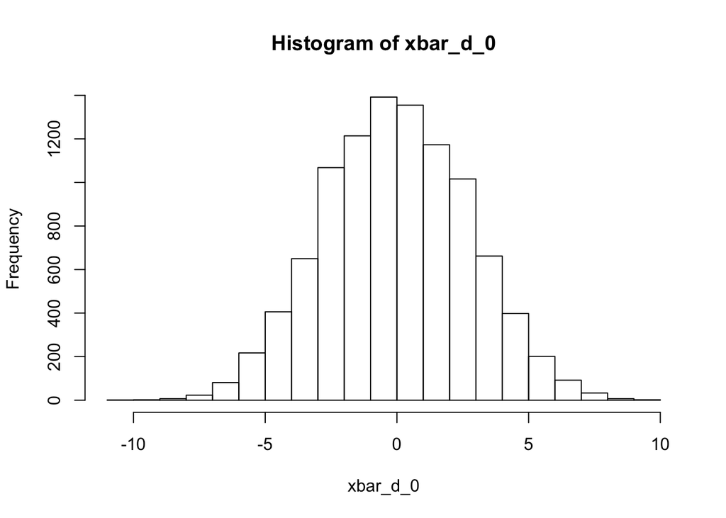

```r
hist(xbar_d_0)
```

Now we can compare our actual difference in sample means to this distribution.

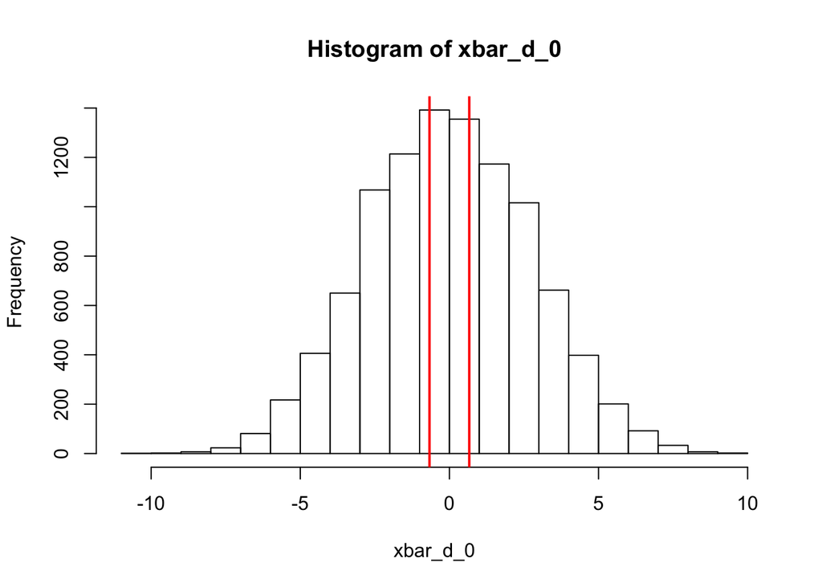

```r
hist(xbar_d_0)
abline(v=xbar_d*c(-1,1), lwd=2, col="red")
```

We can obtain a p-value by counting what fraction of the fake test statistics were more extreme than the actual one:

```r
sum(abs(xbar_d_0) > abs(xbar_d))/N
```

```
## [1] 0.8052
```

### Bootstrapping

Permutation tests are nonparametric analogues of parametric hypothesis tests. Bootstrapping provides a nonparametric analogue of parametric confidence intervals.

Recall that a confidence interval provides us an interval for a population parameter, like the difference in mean pulses between females and males. Whereas the CI from the t-test output heavily relies on normality assumptions of both populations, bootstrapping produces CIs from a simple idea: the population should look like many, many copies of your sample. If we believe this to be true, then by repeatedly resampling from our existing sample (replicated infinitely many times), we can mimic what similar samples might tell us about the population to obtain CIs.

1. Compute your quantity of interest based on the original sample. (Again, in our case, this might be the difference in the sample means.)
2. Let our imaginary population consist of infinite copies of our sample. Simulate new samples from this population. Compute our quantity of interest based on each new sample.
3. Compute an interval based on the distribution of these quantities from Step 2.

#### Step 1

```r
xbar_d <- mean(x$Pulse[x$Gender == "Female"]) - mean(x$Pulse[x$Gender == "Male"])
```

#### Step 2

Note that Step 2 sounds very similar to what we did in Step 2 of the permutation test. The difference is that we are not interested in disrupting the relationship between `Pulse` and `Gender`. We want to preserve entire rows while we sample. Also, because we are imagining the population just consists of infinite copies of our original sample, we will allow for the possibility of getting duplicates in our sample.

```r
set.seed(230)   # we're about to do some random things

N <- 10000    # number of fake datasets (and test statistics) to simulate
xbar_d_b <- rep(NA, N)

for (i in 1:N) {
  rows <- sample(1:nrow(x), replace = TRUE)
  s <- x[rows,c("Gender", "Pulse")]
  xbar_d_b[i] <- mean(s$Pulse[s$Gender == "Female"]) -
    mean(s$Pulse[s$Gender == "Male"])
}
```

#### Step 3

There are actually some options for Step 3. We’ll take the easiest and perhaps most intuitive approach. Given a **bootstrap distribution** from Step 2, we can now take the 0.025 quantiles and 0.975 quantiles of this distribution to obtain our CI for the difference in the population means.

```r
q <- quantile(xbar_d_b, c(0.025, 0.975))
q
```

```
##      2.5%     97.5%
## -6.212376  4.560863
```

Graphically:

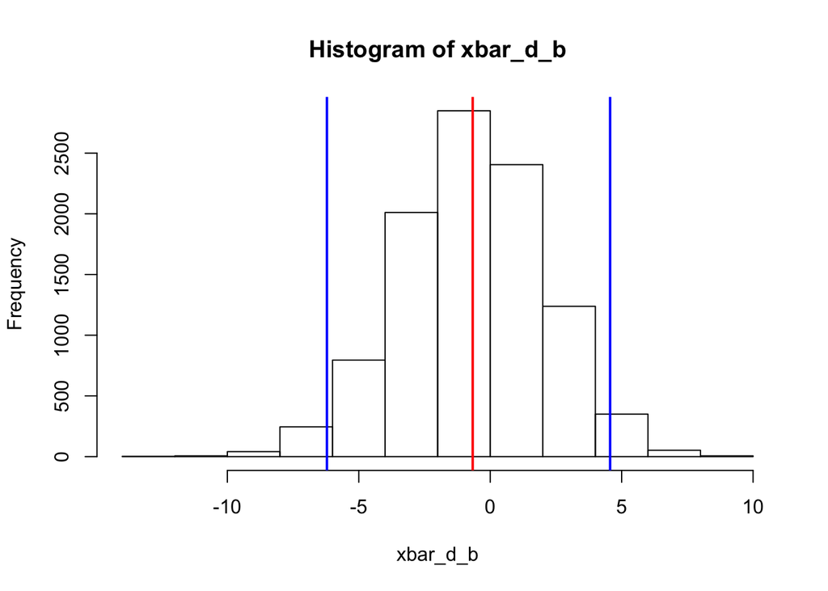

```r
hist(xbar_d_b)
abline(v=xbar_d, col="red", lwd=2)
abline(v=q, col="blue", lwd=2)
```

In cases where your population distributions are not symmetric (maybe heavily skewed), this approach may produce an asymmetric confidence interval, with a larger width on either side of the sample statistic.